# Storm Analysis

### Data Processing

```r
library(data.table)
datadir <- "~/Coursera/Data Science Specialization/Reproducible Research/Project 2/repdata-data-StormData.csv"
dataset <- data.table(read.csv(datadir, header = TRUE))
```

### Results

#### Across the United States, which types of events (as indicated in the `EVTYPE` variable) are most harmful with respect to population health?

The columns associated with health damage are `FATALITIES` and `INJURIES` so we will add up the number of each of those columns with respect to the event type `EVTYPE`.

We look at the top five greatest health damages and compare.

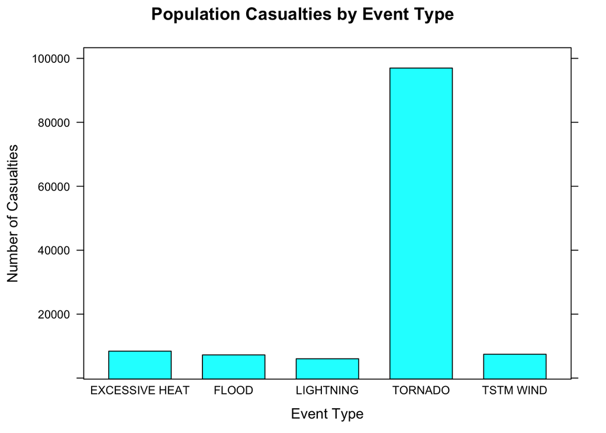

```r
library(lattice)

p1data <- dataset[, list(healthdmg = sum(FATALITIES, INJURIES, na.rm=TRUE)), by = EVTYPE]
p1data <- p1data[order(-healthdmg)][1:5]
barchart(p1data[, healthdmg] ~ p1data[, EVTYPE], xlab = "Event Type", ylab = "Number of Casualties", main = "Population Casualties by Event Type")
```

It is clear that tornadoes are the most impacting to health damages.

#### Across the United States, which types of events have the greatest economic consequences?

Property damage is calculated by `PROPDMG` * `PROPDMGEXP` however there are unknown exponents to multiply by as seen by the following:

```r
dataset[, unique(PROPDMGEXP)]
```

```
##  [1] K M   B m + 0 5 6 ? 4 2 3 h 7 H - 1 8
## Levels:  - ? + 0 1 2 3 4 5 6 7 8 B h H K m M
```

```r
dataset[, .N, keyby = PROPDMGEXP]
```

```
##     PROPDMGEXP      N
##  1:            465934
##  2:          -      1
##  3:          ?      8
##  4:          +      5
##  5:          0    216
##  6:          1     25
##  7:          2     13
##  8:          3      4
##  9:          4      4
## 10:          5     28
## 11:          6      4
## 12:          7      5
## 13:          8      1
## 14:          B     40
## 15:          h      1
## 16:          H      6
## 17:          K 424665
## 18:          m      7
## 19:          M  11330
```

Clearly some of these are nonsense and belong to an untidy dataset. Because there is a relatively small set in the untidy exponents we will restrict to the (“”, “h”, “H”, “k”, “K”, “m”, “M”, “B”) cases.

```r
dataset <- dataset[PROPDMGEXP %in% c("", "h", "H", "k", "K", "m", "M", "B")]
```

Now we convert those exponents into the appropriate magnitudes and can then calculate the total property damage.

```r
expconversion <- data.table(
  PROPDMGEXP = c("", "h", "H", "k", "K", "m", "M", "B"),
  EXPMAG = c(1, 100, 100, 1000, 1000, 1000000, 1000000, 1000000000))
p2data <- merge(dataset, expconversion, by = "PROPDMGEXP", all.x = TRUE)
p2data[, PROPDMGEST := PROPDMG * EXPMAG]
```

[output not shown]

[output cut: 81 more lines]

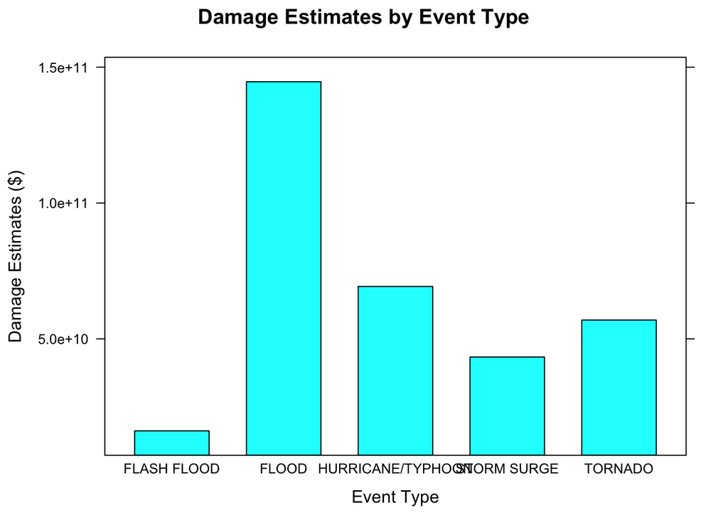

```r
p2data <- p2data[, list(PROPDMGEST = sum(PROPDMGEST, na.rm=TRUE)), by = EVTYPE]
p2data <- p2data[order(-PROPDMGEST)][1:5]

barchart(p2data[, PROPDMGEST] ~ p2data[, EVTYPE], xlab = "Event Type", ylab = "Damage Estimates ($)", main = "Damage Estimates by Event Type")
```

We see here that flooding is the most damaging to property costs.